# Prosper loans

##### Most loans are for debit consolidation.

### 11. LOAN AMOUNT AND NUMBER OF INVESTORS. A high loan amount needs more investors?

[figure not shown]

##### As loan amounts increase, more investors are needed to finance it.

##### Recode LoanStatus to create a new category Defaulted_Chargedoff which combines Chargedoff and Defaulted borrowers into a single category:

```
## # A tibble: 5 × 2
##          LoanStatus_rec2     N
##                    <chr> <int>
## 1              Completed 19651
## 2                Current 55730
## 3   Defaulted_Chargedoff  6341
## 4 FinalPaymentInProgress   203
## 5                PastDue  2057
```

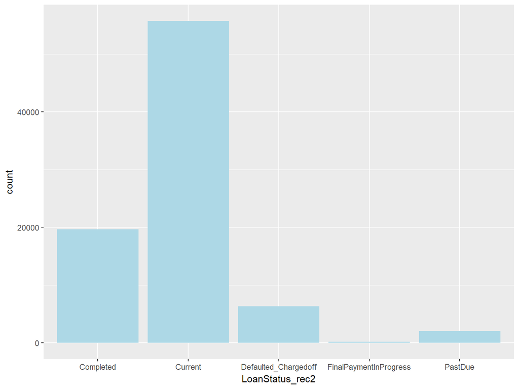

### 12. RELATIONSHIPS BETWEEN DEFAULTED STATUS AND FINANCIAL INFORMATIONS ABOUT BORROWERS

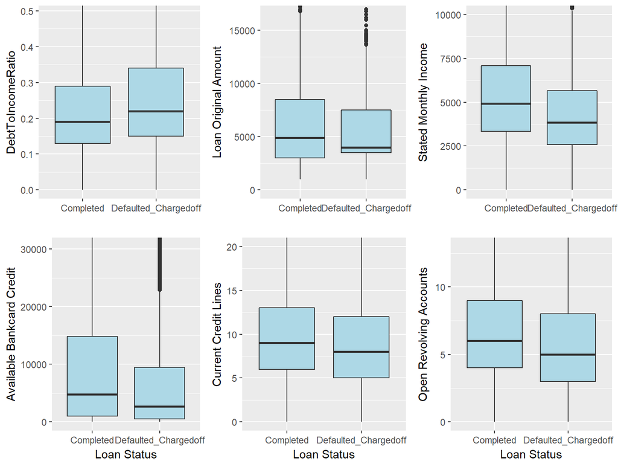

##### Compared to the borrowers who completed the loan payment, the borrower who defaulted have higer debt to income ratio, lower income, lower bankcard credit. These are people who borrow small amount of money.

## Bivariate Analysis

### Talk about some of the relationships you observed in this part of the investigation. How did the feature(s) of interest vary with other features in the dataset?

##### - The number of loans in A,B,C categories have an ascending trend over years, while D,E,HR tend to descrease.

##### - Week positive association of 0.43 between loan amount and prosper score.

##### - High risk clients E and HR are borrowing less money.

##### - Borower rate is higher for small loans and descreases as loans increase.There is a week negative association of -0.41 between loan amount and borrower rate.

##### - Usually, for small amounts of money, the loans are made on 12 months term. As the loan amounts increase, the term is also increasing.

##### - Compared to the borrowers who completed the loan payment, the borrower who defaulted have higer debt to income ratio, lower income, lower bankcard credit.

##### - There are better Prosper scores for higher incomes.

##### - Those with undeclared income ($0 or NA) are scored worse, mostly in HR, E and D category.

##### - Worse Prosper scores for those with high Debt To Income Ratio.

### Did you observe any interesting relationships between the other features (not the main feature(s) of interest)?

##### - The number of investors is growing when the large loans amount.

##### - Most loans are for debit consolidation.

### What was the strongest relationship you found?

##### There’s a high negative correlation of -0.95 between borrower rate and prosper score.

# MULTIVARIATE PLOTS SECTION

### 1. QUARTERLY NUMBER AND AMOUNT OF LOANS BY PROSPER SCORE

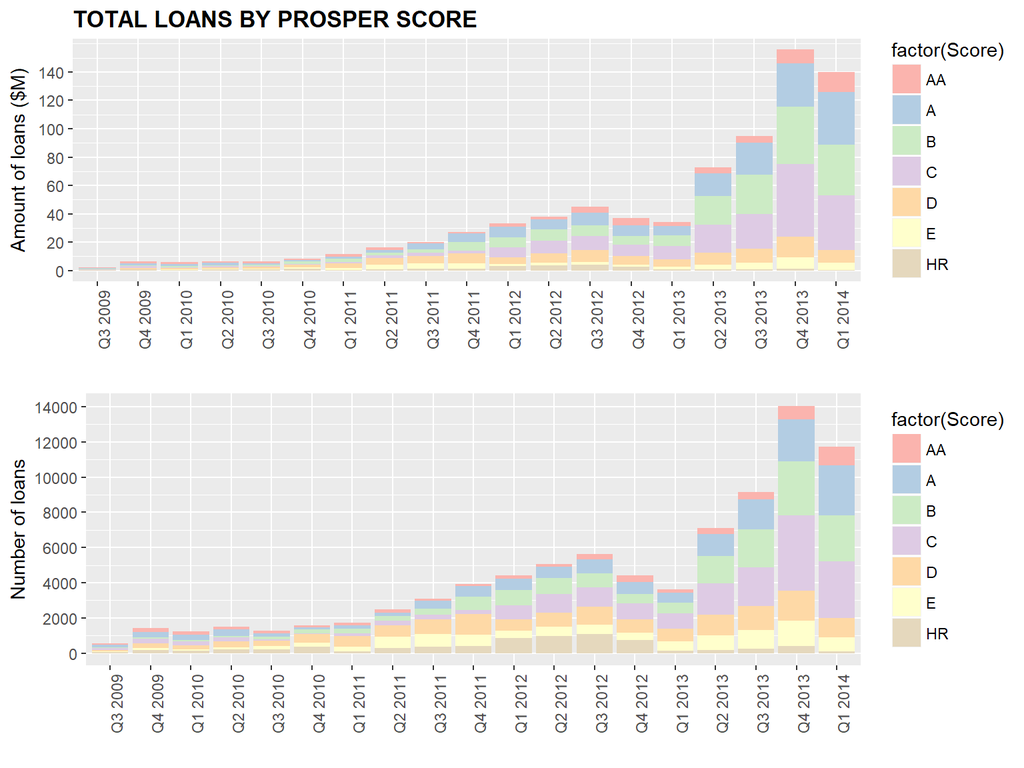

### 2.BORROWER RATE/LENDER YIELD/LOAN AMOUNT MEANS BY PROSPER SCORE YEARLY EVOLUTION

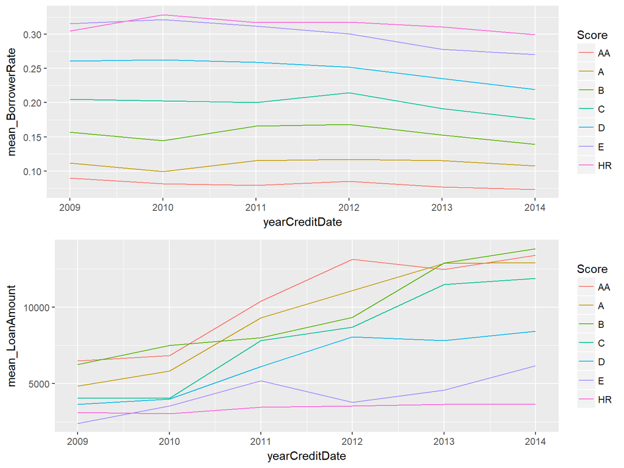

### 3.BORROWER RATE, LOAN AMOUNT AND PROSPER SCORE

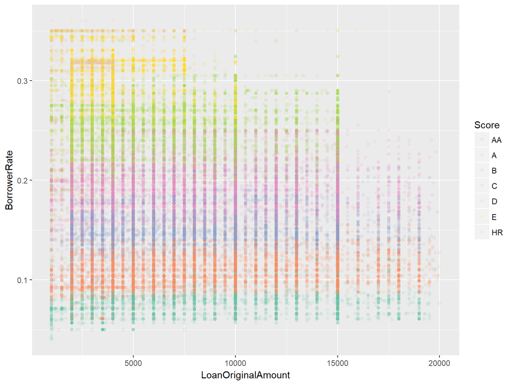

##### The borrowers with higher scores have lower rates. E and HR categories borrow less money, but they pay highest rates.

### 4. YEAR WHEN THE CREDIT WAS TAKEN AND THE DEFAULTED STATUS

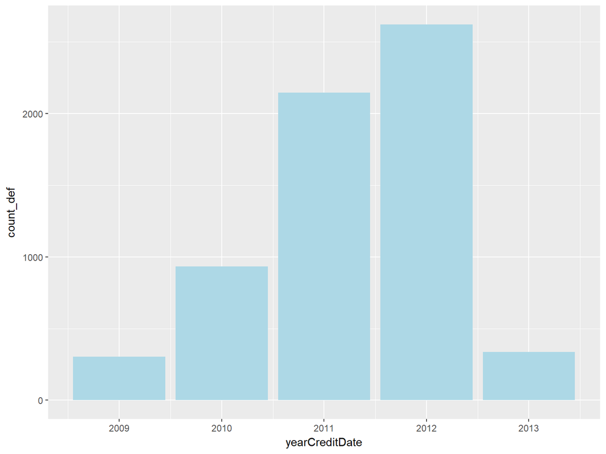

##### We see an increase in 2011 and 2012, but that doesn’t necessarily mean that loans originated in these periods defaulted more.

##### The number of loans started to significant increase in 2011, so more loans result in more chances to default. 2013 has low counts most probably because the short time since credit was taken.A different approach is needed (see the final section of this project)

### 5. DEFAULTS PER YEAR AND SCORE

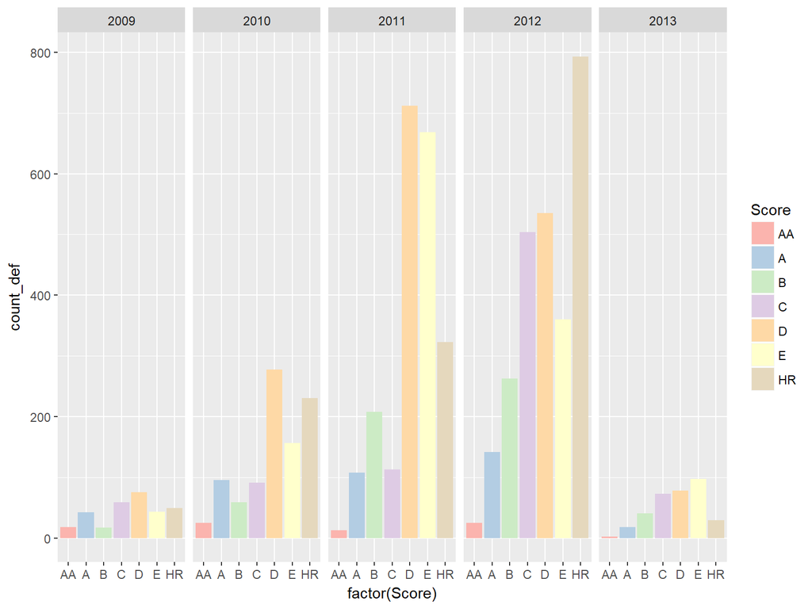

##### Most of defaults happen from D,E,HR categories. In 2012, there was a a very high increase of defaults in C and HR categories.

### 6. After how many months since credit was initiated do borrowers default?

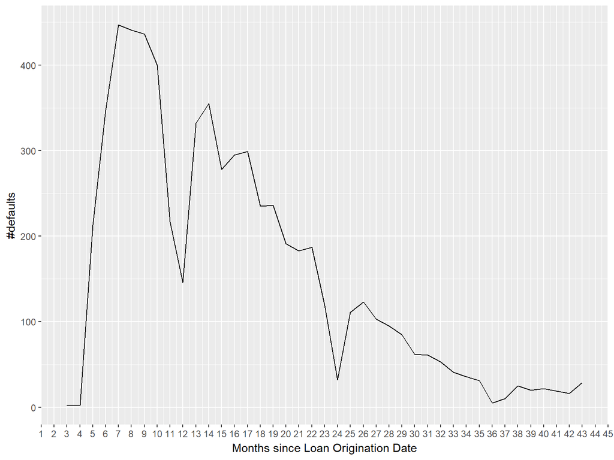

###### There is a huge peak around the 6th month after the credit was originated, then the trend is descending, with a second peak around the 14th month.

### 7. AFTER HOW MANY AVERAGE WEEKS SINCE LOAN ORIGINATION DO BORROWERS OF EACH PROSPER SCORE CATEGORY DEFALUT ?

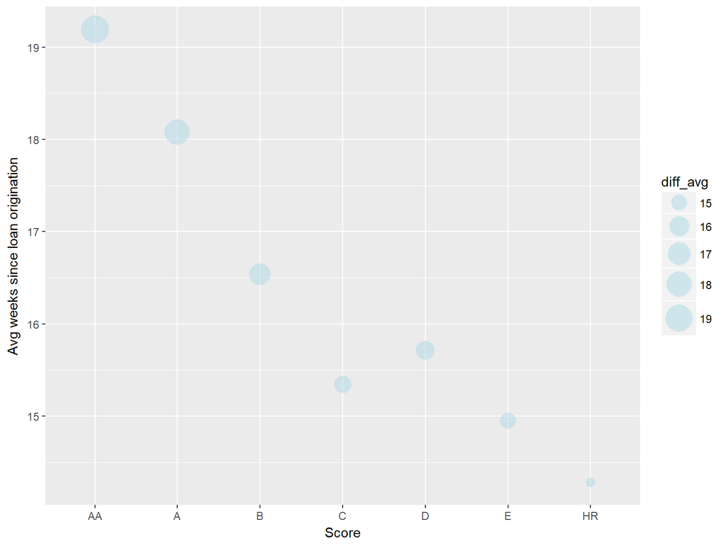

##### As the Prosper score is better, the default is happening later, after more weeks since loan origination.

## Multivariate Analysis

### Talk about some of the relationships you observed in this part of the investigation. Were there features that strengthened each other in terms of looking at your feature(s) of interest?

##### - For higher Prosper score the default happens later.

### Were there any interesting or surprising interactions between features?

##### I didn’t expect to find such nice delimitations in the scatterplot of borrower rate, loan amount and prosper score.

##### I knew that the rate was influenced by the score, but I was expecting a higher variation among loan amount.

### OPTIONAL: Did you create any models with your dataset? Discuss the strengths and limitations of your model.

##### I created a logistic regression model to predict the borrowers with default risk.

##### From the variables I initialy selected, I removed the ones which were not significant for the model and rebuilt the model with only the significant features.

##### Measuring the accuracy of the model on the test set, at a trashhold cutoff equal to 0.5, I got 75.9% accuracy, 10% sensitivity and 97% specificity. The baseline model accuracy was 75.6%.Ploting the ROC curve and calculating the AUC (area under the curve) which is typical performance measurement for a binary classifier, I got AUC=0.72.

##### The sensitivity score I obtained is very low, only 10%. This means that the model identify only 10% of the true positives (borrowers who are likely to default). But, a credit company is likely to be more concerned with sensititivy because this way they can reduce the risk. Therefore, they may be more concerned with tuning a model so that their sensititivy is improved.I played with the trashhold cutoff to see how the accuracy of the model is changing. If I decrease the cutoff, the sensitivity is increasing but at the cost of a lower overall accuracy and specificity. Playing around with the trashhold cutoff, the features included in model or even using a more complex model, the accuracy may be improved.

## Final Plots and Summary

### Plot One

### % OF DEFAULTS BY PROSPER SCORE AND CREDIT ORIGINATED DATE

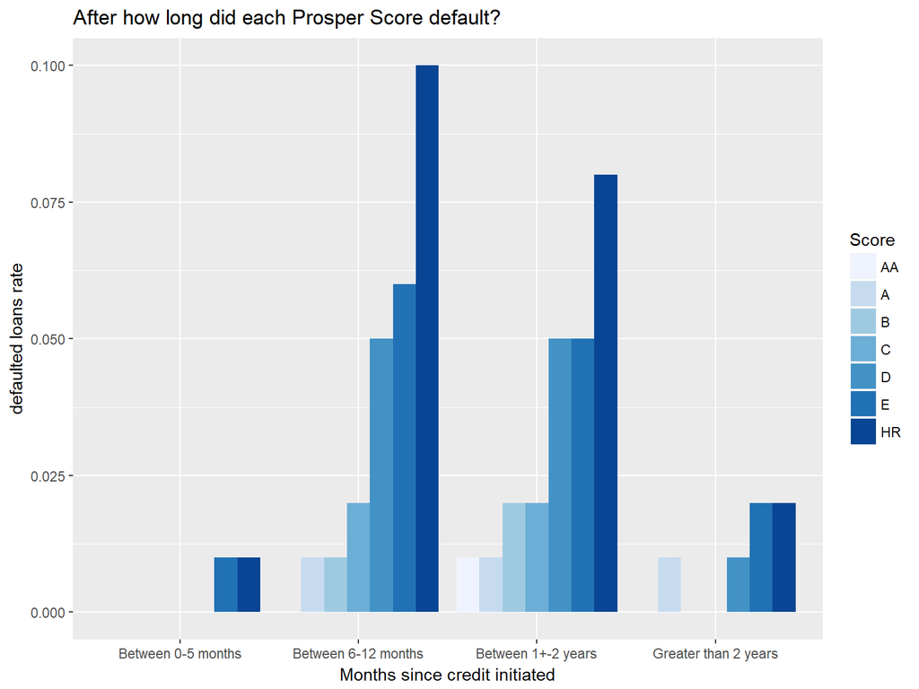

### Plot Two

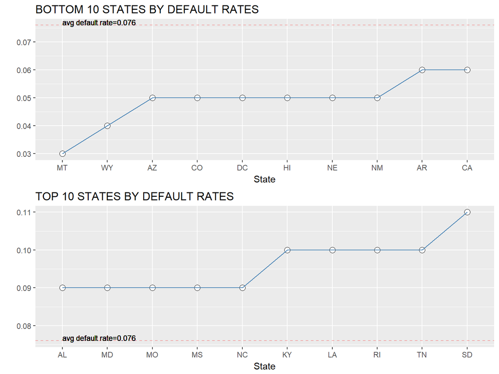

### Plot Three

### DEFAULTED VS COMPLETED BORROWERS COMPARISON: Avg borrower rate / Avg Stated Monthly Income / Avg Debt to Income ratio FOR EACH PROSPER SCORE

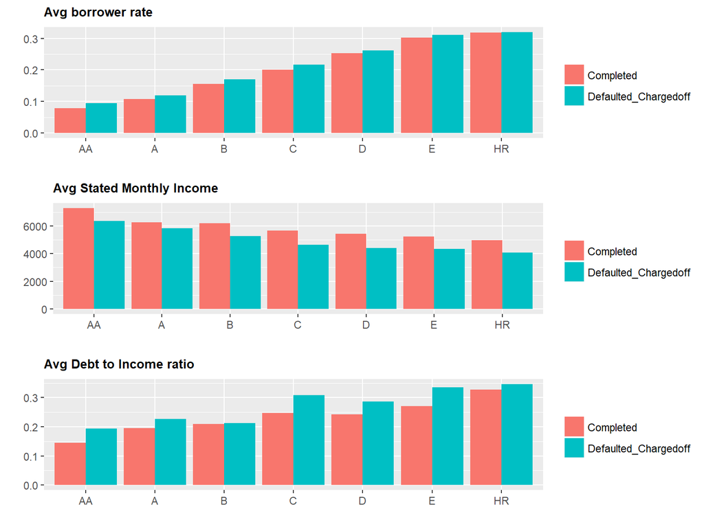

### Description Three

##### Borrowers who defaulted had an average borrower rate greater than those who completed the payment. The avg rate is increasing with each score, putting more pressure on the borrowers who were classified in a low score category and making it harder to pay the loan.

##### Those who defaulted had an avg monthly income lower than those who completed the payment across all score categories. This two facors make the avg debt to income ratio to increase by score and to have higher values for borrowers who defaulted compared with those who didn’t. So a smaller income and a high borrower rate have an important impact on the success of completing the payment or not.

# Reflection

##### The difficulties I encounter with the dataset were mainly related to the financial terms. I didn’t know anything about peer-to-peer lending company, in Romania the legislation doesn’t allow such companies to exist.

##### After an initial quick summary run on the dataset, I noticed many missings, inexplicable values of 0 and an inconsistency in the Prosper Score categories. Exploring the data, I removed the duplicates and decided to keep only the loans from July 2009 to March 2014 which solved many of the issues.

##### I started the EDA by running some simple plots to make sense of the data and to find a possible scenario to present.

##### But every new plot rised new questions and each question could be answered in many ways. I think I spent most of my time searching for a story to tell. After I did few plots to reveal the loans trend as values and numbers, I become curious about one thing: which variables influence the prosper score? Seeing the behaviour of each category in prosper score, the next curiosity was: which of these borrowers will not complete their payment and why? Answering this questions helped me to develop a logistic regression to predict risky borrowers. The model can be improved,but I learned a lot about a simple machine learning algorithm and it was a great experience.